# A3 Classifying Text Spam

Yifan Luo (骆轶凡)

2020/5/17

# Question 1

## Data Cleaning

```r
library(tidyverse)
library(rpart)
library(rattle)
```

```r
library(rpart.plot)
library(caret)
```

From `data_description.txt` load our workspace.

```r
load("./datasets/spam.rda")
```

It contains three members, let’s have a first look.

- df

```r
dim(df)
```

```
## [1] 5574    3
```

```r
head(df)
```

```
##                                                                                                                                                                text
## 1                                              ham\tGo until jurong point, crazy.. Available only in bugis n great world la e buffet... Cine there got amore wat...
## 2                                                                                                                                ham\tOk lar... Joking wif u oni...
## 3 spam\tFree entry in 2 a wkly comp to win FA Cup final tkts 21st May 2005. Text FA to 87121 to receive entry question(std txt rate)T&C's apply 08452810075over18's
## 4                                                                                                            ham\tU dun say so early hor... U c already then say...
## 5                                                                                                ham\tNah I don't think he goes to usf, he lives around here though
## 6        spam\tFreeMsg Hey there darling it's been 3 week's now and no word back! I'd like some fun you up for it still? Tb ok! XxX std chgs to send, 拢1.50 to rcv
##   is_spam
## 1   FALSE
## 2   FALSE
## 3    TRUE
## 4   FALSE
## 5   FALSE
## 6    TRUE
##                                                                                                                                                                                       words
## 1                                                 Go, until, jurong, point, , crazy, , , Available, only, in, bugis, n, great, world, la, e, buffet, , , , Cine, there, got, amore, wat, ,
## 2                                                                                                                                                    Ok, lar, , , , Joking, wif, u, oni, ,
## 3 Free, entry, in, 2, a, wkly, comp, to, win, FA, Cup, final, tkts, 21st, May, 2005, , Text, FA, to, 87121, to, receive, entry, question, std, txt, rate, T&C's, apply, 08452810075over18's
## 4                                                                                                                           U, dun, say, so, early, hor, , , , U, c, already, then, say, ,
## 5                                                                                                                Nah, I, don't, think, he, goes, to, usf, , he, lives, around, here, though
## 6  FreeMsg, Hey, there, darling, it's, been, 3, week's, now, and, no, word, back, , I'd, like, some, fun, you, up, for, it, still, , Tb, ok, , XxX, std, chgs, to, send, , 拢1, 50, to, rcv
```

```r
sum(is.na(df))
```

```
## [1] 0
```

No NA values.

- wordmatrix

```r
dim(wordmatrix)
```

```
## [1] 5574  630
```

```r
head(wordmatrix, 1)
```

```
##      w_ w_- w_'' w_" w_* w_& w_&amp; w_&lt;#&gt; w_&lt;DECIMAL&gt; w_+ w_拢1
## [1,]  8   0    0   0   0   0       0           0                 0   0     0
##      w_拢100 w_拢1000 w_拢5000 w_000 w_1 w_10 w_150p w_150ppm w_16 w_16+ w_18
## [1,]       0        0        0     0   0    0      0        0    0     0    0
##      w_1st w_2 w_2nd w_3 w_4 w_4* w_5 w_50 w_500 w_6 w_7 w_8 w_8007 w_9 w_a w_A
## [1,]     0   0     0   0   0    0   0    0     0   0   0   0      0   0   0   0
##      w_able w_about w_abt w_account w_actually w_address w_after w_afternoon
## [1,]      0       0     0         0          0         0       0           0
##      w_again w_ah w_Aight w_all w_All w_already w_also w_always w_am w_Am w_an
## [1,]       0    0       0     0     0         0      0        0    0    0    0
##      w_and w_And w_another w_any w_anything w_apply w_are w_Are w_around w_as
## [1,]     0     0         0     0          0       0     0     0        0    0
##      w_As w_ask w_asked w_at w_AT w_attempt w_award w_awarded w_away w_b w_babe
## [1,]    0     0       0    0    0         0       0         0      0   0      0
##      w_baby w_back w_bad w_be w_because w_bed w_been w_before w_being w_best
## [1,]      0      0     0    0         0     0      0        0       0      0
##      w_better w_between w_big w_birthday w_bit w_Box w_boy w_bring w_bus w_but
## [1,]        0         0     0          0     0     0     0       0     0     0
##      w_But w_buy w_by w_c w_C w_call w_Call w_CALL w_called w_calls w_came
## [1,]     0     0    0   0   0      0      0      0        0       0      0
##      w_camera w_can w_Can w_can't w_cant w_car w_care w_cash w_chance w_chat
## [1,]        0     0     0       0      0     0      0      0        0      0
##      w_check w_claim w_Claim w_class w_co w_collect w_collection w_com w_come
## [1,]       0       0       0       0    0         0            0     0      0
##      w_comes w_coming w_contact w_cool w_cos w_could w_customer w_d w_da w_dat
## [1,]       0        0         0      0     0       0          0   0    0     0
##      w_day w_days w_de w_dear w_Dear w_den w_details w_did w_Did w_didn't
## [1,]     0      0    0      0      0     0         0     0     0        0
##      w_didnt w_dinner w_dis w_do w_Do w_does w_doing w_don't w_Don't w_done
## [1,]       0        0     0    0    0      0       0       0       0      0
##      w_dont w_Dont w_down w_draw w_driving w_dun w_e w_early w_easy w_eat
## [1,]      0      0      0      0         0     0   1       0      0     0
##      w_either w_else w_end w_enough w_entry w_even w_evening w_ever w_every
## [1,]        0      0     0        0       0      0         0      0       0
##      w_everything w_face w_family w_feel w_feeling w_few w_find w_fine w_finish
## [1,]            0      0        0      0         0     0      0      0        0
##      w_first w_food w_for w_For w_forgot w_free w_Free w_FREE w_friend
## [1,]       0      0     0     0        0      0      0      0        0
##      w_friends w_from w_fun w_get w_Get w_getting w_gift w_girl w_give w_go
## [1,]         0      0     0     0     0         0      0      0      0    0
```

[output cut: 69 more lines]

```
## [1,]    0    0    0        0    0     0   0   0       0      0      0         0
##      w_wake w_wan w_wanna w_want w_wanted w_wants w_was w_wat w_Wat w_watch
## [1,]      0     0       0      0        0       0     0     1     0       0
##      w_watching w_way w_we w_We w_week w_weekend w_weekly w_well w_Well w_went
## [1,]          0     0    0    0      0         0        0      0      0      0
##      w_were w_what w_What w_when w_When w_where w_Where w_which w_while w_who
## [1,]      0      0      0      0      0       0       0       0       0     0
##      w_why w_Why w_wif w_will w_Will w_win w_wish w_with w_without w_won w_WON
## [1,]     0     0     0      0      0     0      0      0         0     0     0
##      w_won't w_wont w_word w_work w_working w_world w_worry w_would w_www w_x
## [1,]       0      0      0      0         0       1       0       0     0   0
##      w_y w_ya w_Ya w_yeah w_Yeah w_year w_years w_Yes w_yesterday w_yet w_Yo
## [1,]   0    0    0      0      0      0       0     0           0     0    0
##      w_you w_You w_YOU w_you're w_your w_Your w_yours w_Yup
## [1,]     0     0     0        0      0      0       0     0
```

```r
sum(is.na(wordmatrix))
```

```
## [1] 0
```

- common_words

```r
summary(common_words)
```

```
##    Length     Class      Mode
##       630 character character
```

```r
head(common_words)
```

```
## [1] ""   "-"  "''" "\"" "*"  "&"
```

No any suspicious data, no any data cleaning yet.

## Model Fitting

According to the description, we use `rpart` to fit a tree model.

```r
# y is a factor so we use "class" model
# ref: https://www.rdocumentation.org/packages/rpart/versions/4.1-15/topics/rpart
tree <- rpart(df$is_spam ~ wordmatrix, method = "class", na.action = na.omit)
```

## Predicting and Plotting

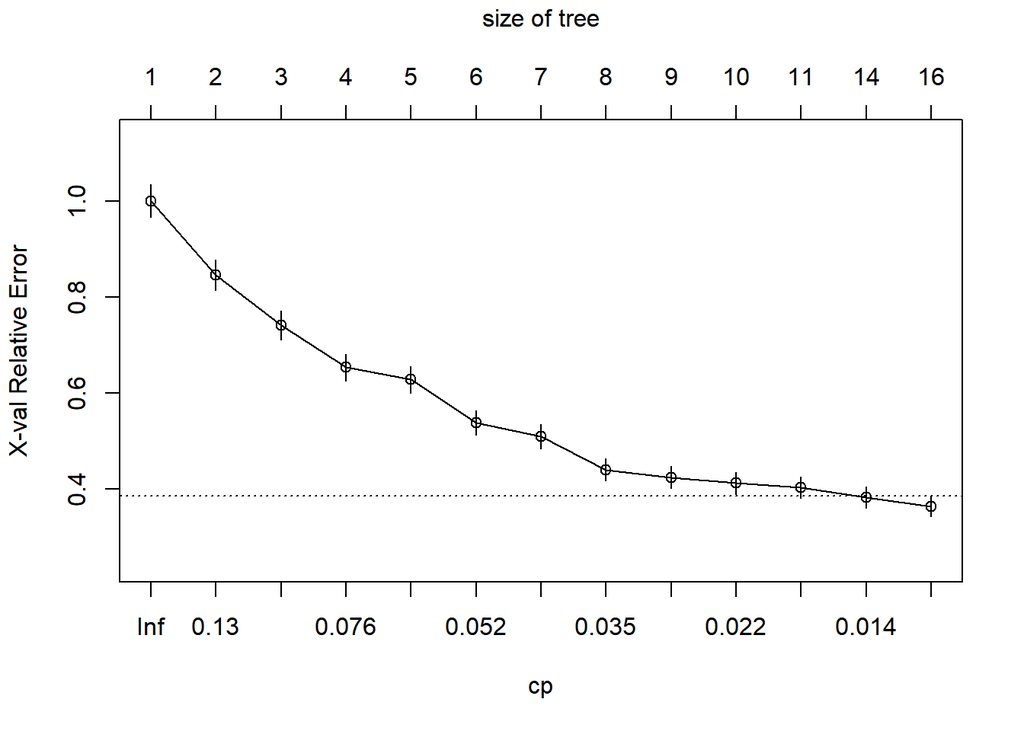

```r
pred <- predict(tree, type = "class")
plotcp(tree)
```

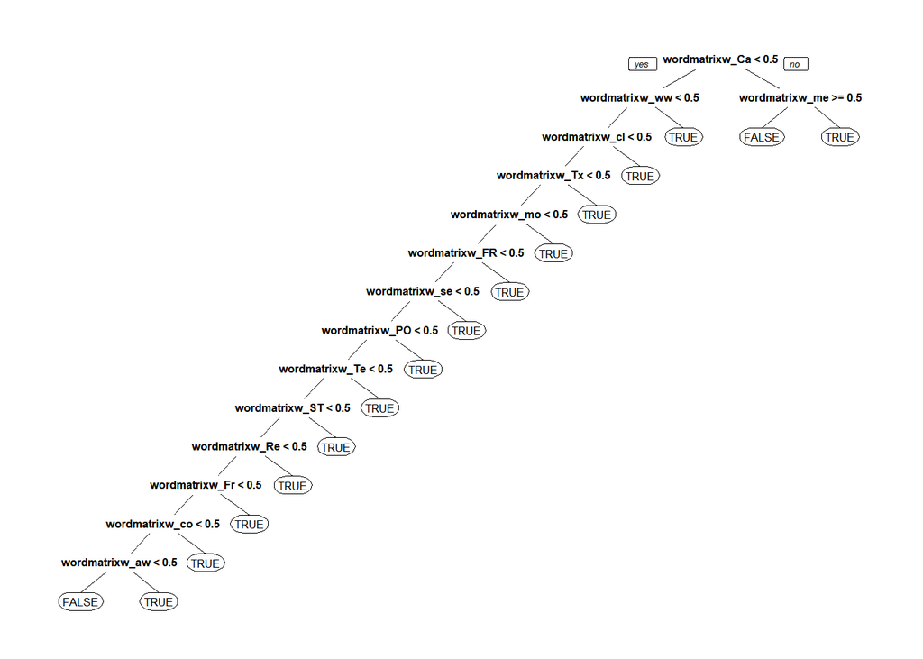

```r
prp(tree)
```

```r
printcp(tree)
```

```
##
## Classification tree:
## rpart(formula = df$is_spam ~ wordmatrix, na.action = na.omit,
##     method = "class")
##
## Variables actually used in tree construction:
##  [1] wordmatrixw_awarded    wordmatrixw_Call       wordmatrixw_claim
##  [4] wordmatrixw_collection wordmatrixw_Free       wordmatrixw_FREE
##  [7] wordmatrixw_me         wordmatrixw_mobile     wordmatrixw_PO
## [10] wordmatrixw_Reply      wordmatrixw_service    wordmatrixw_STOP
## [13] wordmatrixw_Text       wordmatrixw_Txt        wordmatrixw_www
##
## Root node error: 747/5574 = 0.13402
##
## n= 5574
##
##          CP nsplit rel error  xerror     xstd
## 1  0.153949      0   1.00000 1.00000 0.034048
## 2  0.104418      1   0.84605 0.84605 0.031689
## 3  0.088353      2   0.74163 0.74163 0.029902
## 4  0.065596      3   0.65328 0.65328 0.028248
## 5  0.060241      4   0.58768 0.62784 0.027745
## 6  0.044177      5   0.52744 0.53815 0.025855
## 7  0.042838      6   0.48327 0.51004 0.025221
## 8  0.028112      7   0.44043 0.44043 0.023554
## 9  0.022758      8   0.41232 0.42436 0.023147
## 10 0.021419      9   0.38956 0.41232 0.022836
## 11 0.014279     10   0.36814 0.40295 0.022590
## 12 0.013387     13   0.32530 0.38286 0.022051
## 13 0.010000     15   0.29853 0.36412 0.021533
```

## Prunning

Let’s check out if we need to prune the tree.

```r
ptree <- prune(tree, cp = tree$cptable[which.min(tree$cptable[,"xerror"]),"CP"])
```

```r
printcp(ptree)
```

```
##
## Classification tree:
## rpart(formula = df$is_spam ~ wordmatrix, na.action = na.omit,
##     method = "class")
##
## Variables actually used in tree construction:
##  [1] wordmatrixw_awarded    wordmatrixw_Call       wordmatrixw_claim
##  [4] wordmatrixw_collection wordmatrixw_Free       wordmatrixw_FREE
##  [7] wordmatrixw_me         wordmatrixw_mobile     wordmatrixw_PO
## [10] wordmatrixw_Reply      wordmatrixw_service    wordmatrixw_STOP
## [13] wordmatrixw_Text       wordmatrixw_Txt        wordmatrixw_www
##
## Root node error: 747/5574 = 0.13402
##
## n= 5574
##
##          CP nsplit rel error  xerror     xstd
## 1  0.153949      0   1.00000 1.00000 0.034048
## 2  0.104418      1   0.84605 0.84605 0.031689
## 3  0.088353      2   0.74163 0.74163 0.029902
## 4  0.065596      3   0.65328 0.65328 0.028248
## 5  0.060241      4   0.58768 0.62784 0.027745
## 6  0.044177      5   0.52744 0.53815 0.025855
## 7  0.042838      6   0.48327 0.51004 0.025221
## 8  0.028112      7   0.44043 0.44043 0.023554
## 9  0.022758      8   0.41232 0.42436 0.023147
## 10 0.021419      9   0.38956 0.41232 0.022836
## 11 0.014279     10   0.36814 0.40295 0.022590
## 12 0.013387     13   0.32530 0.38286 0.022051
## 13 0.010000     15   0.29853 0.36412 0.021533
```

No need to prune. The pruned tree is exactly the previous one.

It implies we have used the minimum `xerror` tree. Otherwise, an alternative is to use the smallest tree that is within 1 standard error of the best tree (the one we’ve selected).

## Confusion Matrix

```r
true <- df$is_spam %>%
  as.factor()

confusionMatrix(pred, true)
```

```
## Confusion Matrix and Statistics
##
##           Reference
## Prediction FALSE TRUE
##      FALSE  4785  181
##      TRUE     42  566
##
##                Accuracy : 0.96
##                  95% CI : (0.9545, 0.965)
##     No Information Rate : 0.866
##     P-Value [Acc > NIR] : < 2.2e-16
##
##                   Kappa : 0.8129
##
##  Mcnemar's Test P-Value : < 2.2e-16
##
##             Sensitivity : 0.9913
##             Specificity : 0.7577
##          Pos Pred Value : 0.9636
##          Neg Pred Value : 0.9309
##              Prevalence : 0.8660
##          Detection Rate : 0.8584
##    Detection Prevalence : 0.8909
##       Balanced Accuracy : 0.8745
##
##        'Positive' Class : FALSE
##
```

We also got other statistics from the table above.

High accuracy (0.96) and super high sensitivity (0.99), but specificity (0.76) is not as good as the previous ones.

# Question 2

## Statistics Computing

```r
y <- c()
n <- c()
e <- c()

# calculate the times they present in spam and ham
for (i in 1:ncol(wordmatrix)){
  y[i] <- sum(wordmatrix[df$is_spam, i])  # number of attendance
  n[i] <- sum(wordmatrix[!df$is_spam, i])  # number ofabsence
  e[i] <- log(y[i]+1) - log(n[i]+1)  # evdience level
}

score <- (wordmatrix > 0) %*% e  # matrix multiply
```

The `e[i]` is assumed to represent the importance of ith word in spam classification. Higher value implies higher probability to classified as a spam.

Each row of `score` represents the evidence level of a sentence, same as `e[i]`, higher value implies higher probability to classified as a spam.

## Threshold and Confusion Matrix

According to the assignment description, we need to make sure that the proportion of spam predicted is equal to the proportion observed.

```r
threshold <- quantile(score, 1 - sum(df$is_spam)/nrow(wordmatrix))

threshold
```

```
## 86.59849%
##  -5.01728
```

```r
table(df$is_spam, score>threshold)
```

```
##
##         FALSE TRUE
##   FALSE  4585  242
##   TRUE    247  500
```

We can see FP (242) and FN (247) are pretty close.

# Question 3

The UCI archive tells us that our spam data are collected from UK but ham data are from different scources (70% are from Singapore).

People from countries under different culture have various linguistic habits, words even grammars.

Since most of our data are from Singapore, our model may be useful in predicting mails from Singapore. It performs less efficient if a mail is from other country.

In question 2, we set our model with a specific cutoff based on our data set, it will cause kind of “overfitting” and cause generalizability problem if we use our model on different data set.